# Assignment 4 - A working Title

Anthony Luna & Elliott Matthews

11/9/2019

### Introduction

The Marine Managed Areas Improvement Act of 1999 tasked the California Department of Fish and Wildlife (CDFW) to establish a process to designate Marine Protected Areas (MPA) with the goal of protecting sensitive marine ecosystems. On, January 1st, 2012 the coast off of Isla Vista and Naples Point in Santa Barbara County were designated as MPAs (CDFW 2012). Previous studies suggested that marine protected areas are effective at increasing abundance and size of *P.interruptus* (Parnell P. E., et al. 2005), therefore in the interest of quantifying MPA designation impacts in Santa Barbara County, the Santa Barbara Coastal Long Term Ecological Research program (SBC LTR) began conducting annual counts and size measurements of the California spiny lobster (Reed D. 2019). Using collected data, lobster population and size changes over six years were explored. Abundance of lobsters at each site are explored over time, with qualitative information included regarding the individual MPA site regulations. Size distributions are compared over time for each site with the minimum catch size used as a benchmark for comparison between MPA an non-MPA. Finally, statistical analysis is provided to describe the differences in means between the varying populations.

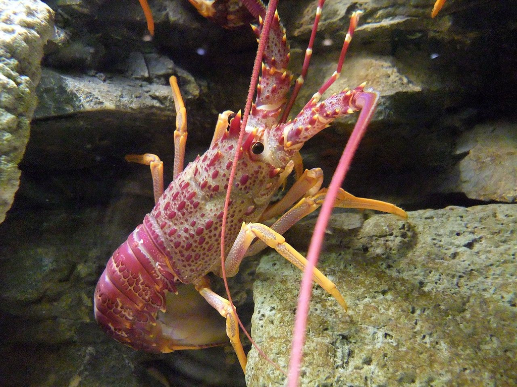

**Figure 1:** *Panulirus interruptus* in its natural habitat. Credit: [Wikipedia, Stemonitis - Own work](https://commons.wikimedia.org/w/index.php?curid=14499898)

### Data and Methods

Collection of size and abundance data for *P. interruptus* began in 2012 and is currently ongoing effort conducted by the Santa Barbara Coastal Long Term Ecological Research program. Data available for this report is from 2012 to 2018, and includes samples taken across 5 unique sites, 2 of which (Isla Vista and Naples) are MPAs. For more information on the collection protocols, see the detailed metadata (Reed D. 2019). A time series plot is provided to visually explore lobster counts by location over time (2012-2018) and differences between varying years are used to describe the variation in lobster count changes over time. A violin plot is used to compare the change of size distributions (mm) for each site from 2012 to 2018. A two sample t-test (Welch’s t-test, $\alpha = 0.05$ throughout) is used to describe the differences between mean sizes (mm) between MPA and Non-MPA sites from 2012 to 2018. All analyses and figures were prepared using R software version 3.6.1.

### Results

#### Results A: Visually Explore changes in annual lobster abundance (counts) by site

Change in counts between 2012 and 2018 shows greatest population increases in the Marine Protected Areas. Isla Vista and Naples increased by 920 and 292 lobsters respectively while Carpinteria, Mohawk, and Arroyo Quemado increased by 265, 81, 16. Comparing the differences from 2012 to 2017, Carpinteria has a larger increase (627) in comparison to both Isla Vista (580) and Naples (106), however Carpinteria has a substatial drop between 2017 and 2018 (-362) which may be attributed to its unproteced status.

##### Isla Vista

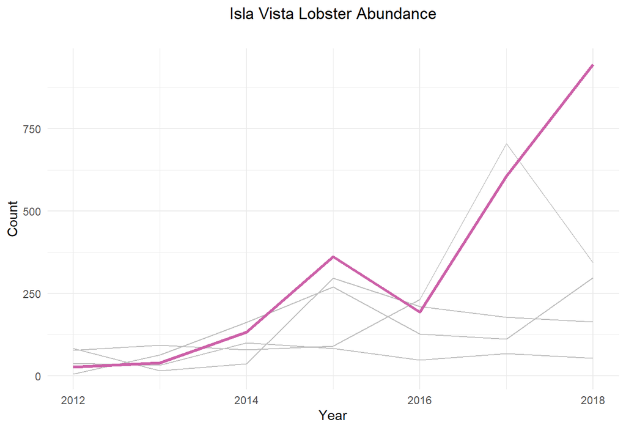

**Figure 1.1**: Isla Vista was desginated a MPA site in January 1st, 2012. Specific designation is State Marine Conservation Area with the individual MPA regulation allowing ecosystem distrubance in the case of the “operation and maintenance of artificial structures inside the conservation area” (CDFW, 2012). This site has the highest change in lobster abundance from 2012 to 2018 (920).

##### Naples

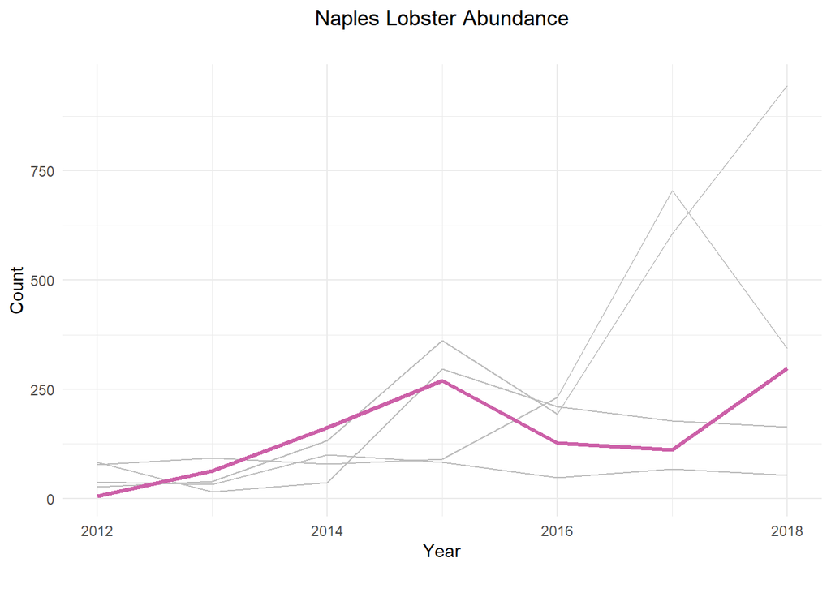

**Figure 1.2**: Naples was desginated a MPA site in January 1st, 2012. Specific designation is State Marine Conservation Area with the individual MPA regulation allowing ecosystem distrubance in the case of “recreational take by spearfishing of white seabass and pelagic finfish”, “commercial take of giant kelp (*Macrocystis pyrifera*) by hand harvest or by mechanical harvest”, or the “operation and maintenance of artificial structures inside the conservation area”. In addition, the Santa Ynez Band of Chumas Indians are “exempt from the area and take regulations found in subsection 632(b)(98) and shall comply with all other existing regulations and statutes” (CDFW, 2012). This site has the second highest change in lobster abundance from 2012 to 2018 (292).

##### Carpinteria

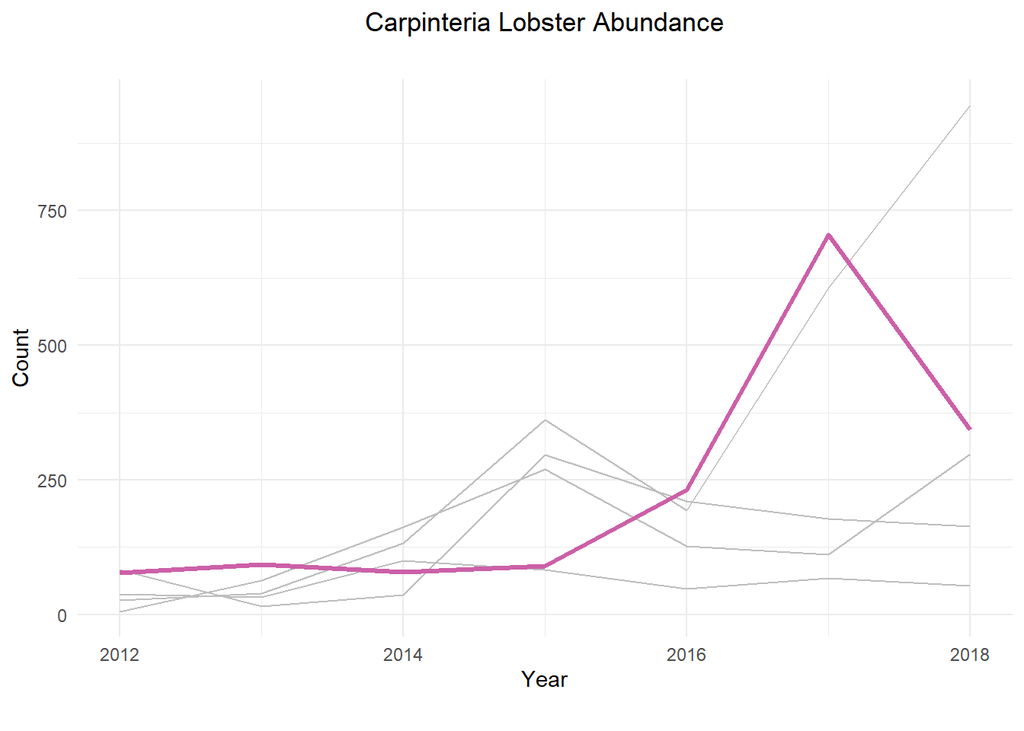

##### Mohawk

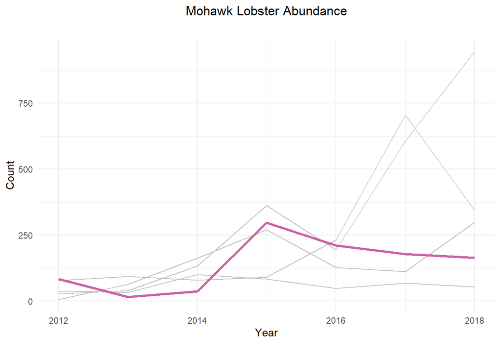

**Figure 1.5**: Mohawk is not a designated MPA site. This site has the second lowest change in lobster abundance from 2012 to 2018 (81).

##### Arroyo Quemado

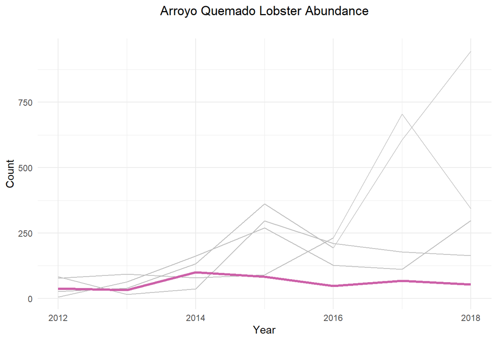

**Figure 1.3**: Arroyo Quemado is not a designated MPA site. This site has the lowest change in lobster abundance from 2012 to 2018 (16)

#### Results B: Visually explore lobster size distribution shifts by comparing lobster sizes in 2012 and 2018

Comparing lobster sizes at catch sites for 2012 and 2018 shows Marine Protected Area lobsters increasing in size. The peak distribution in size at MPA sites shifted closer to the minimum catch size over this period. Non-protected area lobsters on the other hand, remained relatively unchanged in the distributuion of sizes. This increase in density for larger lobsters in the Marine Protected Area suggests more lobsters are surviving longer potentially due to the reduced fishing pressures.

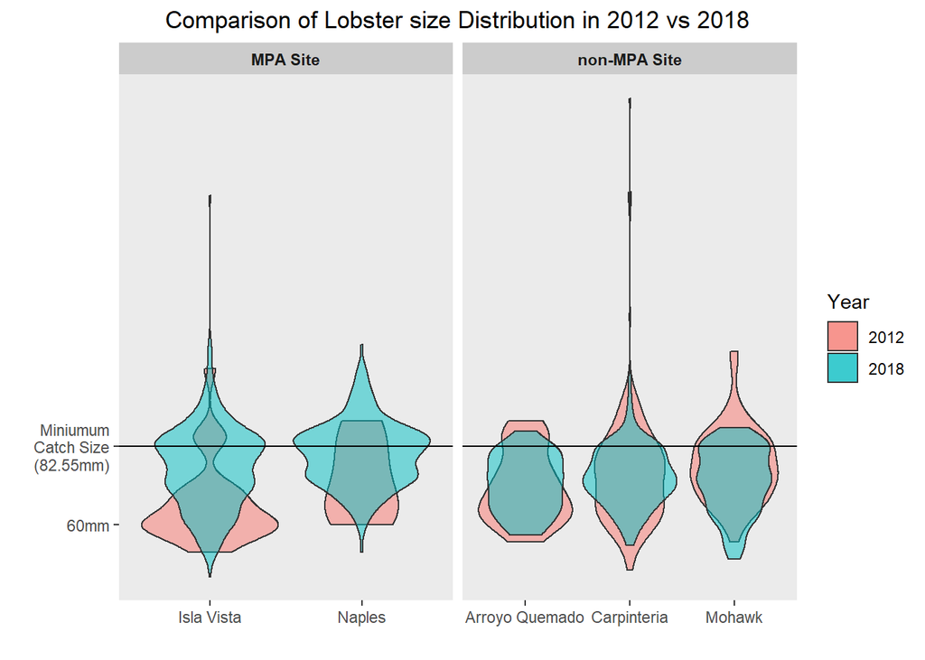

**Figure 2**: Relative distribution of sizes are for each site for 2012 and 2018. The minimum catch size of 82.55mm (Lobster, Spiny. Minimum Size and Verification 2017) is included as a reference point. MPA sites demonstrate a shift from peak distribution far below this reference point to just above, whereas the non-MPA sites show less distributional shift.

#### Results C: Compare mean lobster sizes at MPA vs. non-MPA status sites in 2012 and 2018

Table 1: Lobster summary statistics MPA comparisons

| MPA Desgination | Year | Mean (mm) | σ (± mm) | Count |
| --- | --- | --- | --- | --- |
| MPA Site | 2012 | 67.4 | 12.2 | 32 |
| MPA Site | 2018 | 77.6 | 11.7 | 1244 |
| non-MPA Site | 2012 | 74.9 | 12.4 | 199 |
| non-MPA Site | 2018 | 73.6 | 10.1 | 561 |

##### Comparison of MPA vs Non-MPA sites in 2012 and 2018

The percent difference between the 2012 MPA and Non-MPA lobster size means is 10.6%, with the non-MPA sites having a larger mean size (74.9mm ±12.4 compared to 67.4mm ±12.2). This difference is statistically significant (two-sample t-test, t(42.09) = -3.25, p value = 0.0023), therefore, this finding provides support for the decision to designate these sites with MPA status.

Comparing the sites in 2018, there is a statistically significant difference in lobster size between the MPA and non-MPA sites (two-sample t-test, t(1239.51) = 7.31, p value = 4.88e-13). The percent difference between these means is 5.2%, with the MPA sites having a larger mean size (77.6mm ±11.7 compared to 73.6mm ±10.1). This difference provides evidence that the high MPA status was effective at increasing the size of lobsters in these areas relative to non-MPA sites. This is compounded considering the size difference found between these site types in 2012.

There is a statistically significant difference between 2012 and 2018 MPA sites ( two-sample t-test, t(32.5) = -4.69, p value = 4.76e-05). This was seen as a 14.1% increase in mean size from 2012 to 2018 (67.4mm ±12.2 compared to 77.6mm ±11.7). This difference provides evidence that the MPA status was effective at increasing the size of lobsters over time.

At the non-MPA sites the mean size decreased, but the difference was statistically insignificant ( two-sample t-test, t(296.01) = 1.33, p value = 0.1831). It is likely that the overall size had not changed from 2012 to 2018, which provides further evidence that the MPA status was responsible for the increase seen at MPA sites.

### References

**CDFW. Marine Region. (2012).** *Southern California Marine Protected Areas.* Retrieved from https://www.wildlife.ca.gov/Conservation/Marine/MPAs/Network/Southern-California

**Lobster, Spiny. Minimum Size and Verification, 14 CA ADC § 121.5 (2017)**. Retrieved from https://govt.westlaw.com/calregs/Document/I47A614E11F394A40BB6A48210EB8958E?viewType=FullText&originationContext=documenttoc&transitionType=CategoryPageItem&contextData=(sc.Default)

**Parnell, P. E., Lennert-Cody, C., Geelen, L., Stanley, L. D., & Dayton, P. K. (2005).** *Effectiveness of a small marine reserve in southern california. Marine Ecology Progress Series*, 296, 39-52. Retrieved from https://search-proquest-com.proxy.library.ucsb.edu:9443/docview/17649312?accountid=14522

**Phillips, Bruce F. (2013).** *Lobsters : Biology, management, aquaculture and fisheries (2nd ed.)*. Chichester, West Sussex, UK: Wiley-Blackwell.

**Reed D. (2019).** *SBC LTER: Reef: Abundance, size and fishing effort for California Spiny Lobster (Panulirus interruptus), ongoing since 2012.* Environmental Data Initiative. https://doi.org/10.6073/pasta/a593a675d644fdefb736750b291579a0. Dataset accessed 10/30/2019.